# Viewport

# Viewport is a window into the game world

A `Viewport` renders the world, either in 2D or 3D.

All Godot games come with a “root” viewport to render the world, which is only visible at runtime.

Adding a `Viewport` node to a scene creates another window to the game world and renders it to a texture.

In Godot 3, you use viewports not only for split-screen but also for render targets: anytime you need to render to a texture.

In this guide, you will learn how to:

- Set up a `Viewport`.
- Create split screen multiplayer.
- Take screenshots in your game.
- Place floating nametags on 3D characters.
- Put a 3D character in a 2D world.
- Make 3D portals.

Contents:

Contents:

- Setting up a Viewport
- Viewport’s key features
  - Adjusting the viewport size
  - Using transparency
  - Choosing to use sampling and effects
  - Rendering the Viewport onto an in-game object
- How to use a Viewport in practice
  - Split screen multiplayer
  - Taking screenshots
  - Placing Labels in 3D
  - 3D character in 2D world
  - Changing graphics settings
  - Making 3D Portals
- Your questions
  - How do I move a Viewport node on-screen?
  - How do I change the size of my Viewport?
  - How do I make my screen fit to any window size?
  - How should I structure my scene with a Viewport?
  - How do I hide nodes from a Viewport?
  - How do I change the root viewport resolution at runtime?
  - How do I find out when a node has gone off-screen?
- Troubleshooting
  - Why doesn’t my Viewport show anything?
  - ViewportTexture/Viewport is throwing a lot of errors
  - Viewport is upside-down
  - ViewportTexture: Path to node is invalid
  - No collision in multiplayer
- Pro Tips
  - Clickable buttons in 3D

## Setting up a Viewport

Before we use a `Viewport`, let’s look at how to set one up. Every `Viewport` needs:

1. Child nodes to render.
2. A camera to view its content, at least in 3D.
3. A size to control the render resolution. The higher the value, the more rendering performance the viewport requires.

The `Viewport` itself doesn’t display anything. It only renders its content.

To display a viewport’s content, you can use either a `ViewportContainer` node or a `ViewportTexture` resource which you attach to a `TextureRect`.

Using a `ViewportContainer` is the fastest way to display a `Viewport` on the screen: all you need is to add the `Viewport` as a child of a `ViewportContainer`.

[figure not shown]

We cover how to use a `ViewportTexture` instead later in Rendering the Viewport onto an in-game object.

Make sure the `Viewport` node itself has the *Size* property set in the *Inspector*. You can also enable *Stretch* on its `ViewportContainer` to let the container control the viewport’s resolution dynamically.

Lastly, when adding a `Camera` to your viewport, be sure to set it to *Current* in the *Inspector*.

In 3D, you need at least one `Camera` set to *Current* to view the world. In 2D, a viewport without a camera works and uses the bounds displayed in the 2D main screen.

If a `Viewport` stops rendering in-editor, in-game, or if other issues crop up, check out the Troubleshooting part of this guide.

## Viewport’s key features

Now that we have a `Viewport` set up in a scene, we can look at some key features.

### Adjusting the viewport size

The *Size* property controls the viewport’s base render resolution.

If you’re using a `ViewportContainer`, you can adjust the size of its child viewport by enabling *Stretch*. Then, resize the container in the 2D editor to take control of the child viewport’s *Size*.

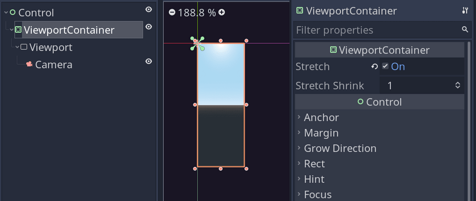

On top of that, `ViewportContainer` offers the *Stretch Shrink* property, which divides the displayed viewport’s resolution. This helps to implement rendering performance settings in your game.

### Using transparency

You can hide the viewport’s background to only render the nodes that the camera sees, without the background. This is really handy for showing a 3D model over a 2D scene, or making a 2D minimap transparent over the game view.

To make your viewport’s background transparent, enable *Transparent Bg* in the *Inspector*.

### Choosing to use sampling and effects

If you’re showing 2D pixel art, you may want to disable sampling to boost performance, and to prevent the viewport from smoothing your pixels.

To do so, set *Rendering -> Usage* to *2D No Sampling*.

For 3D, if you’re not going to use post-processing effects or shaders on a viewport, you can set *3D No Effects* to boost performance.

### Rendering the Viewport onto an in-game object

For every node with a `Texture` property in Godot, the *Inspector* gives the option to add a `ViewportTexture`.

This is also known as a render target: displaying a viewport as a texture. You can use that with `Sprite` nodes, in 3D materials, and anywhere you can display a texture.

To use a `ViewportTexture`:

1. Add a `Viewport` to a scene.
2. On a `Sprite` node or another node with a `Texture` property, assign a new `ViewportTexture` to the slot.
3. A window appears. There, select your `Viewport` node from the scene tree and save the scene.

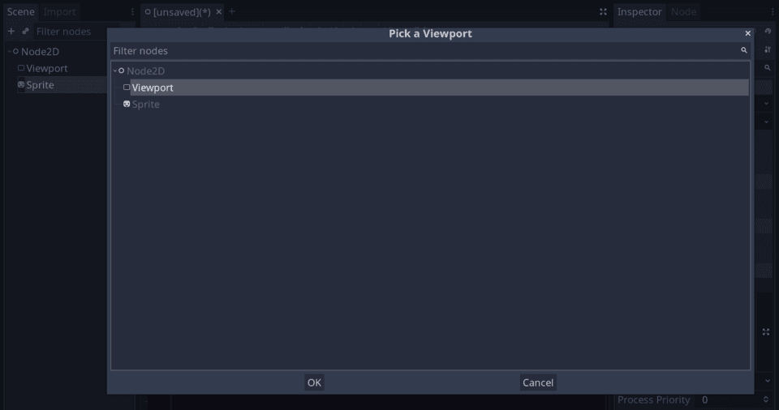

**Note:** Several errors can come up after saving at this point. While most aren’t game-breaking, you can fix them by going to the Troubleshooting section.

## How to use a Viewport in practice

Now let’s take a look at how a `Viewport` node can be used in Godot.

### Split screen multiplayer

To display a split screen, you can use two `ViewportContainer` nodes, each with a child `Viewport`.

Both viewports should have a camera that looks into either the 2D or 3D world.

In this example, we used a `GridContainer` node to automatically place and resize the containers.

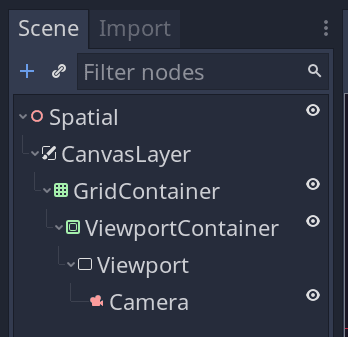

You generally want to turn on *Stretch* on `ViewportContainer` nodes. That way, they’ll resize their viewport to match the displayed area.

To have the `GridContainer` take the entire screen, we placed it inside a `CanvasLayer` and applied *Layout -> Full Rect* to it.

To make sure the `ViewportContainer` fills up the grid too, set its horizontal and vertical *Size Flags* to *Expand*.

You only need the `CanvasLayer` node if, like us, your scene has a `Spatial` node as its root, as this prevents us from changing UI nodes’ layout.

You can read more about `CanvasLayer` nodes in the CanvasLayer guide.

With the split screen set up, you can duplicate the `ViewportContainer` with `Ctrl`+`D` and watch more windows enter the screen. You can adjust the distribution of containers using the *Columns* property on the `GridContainer`.

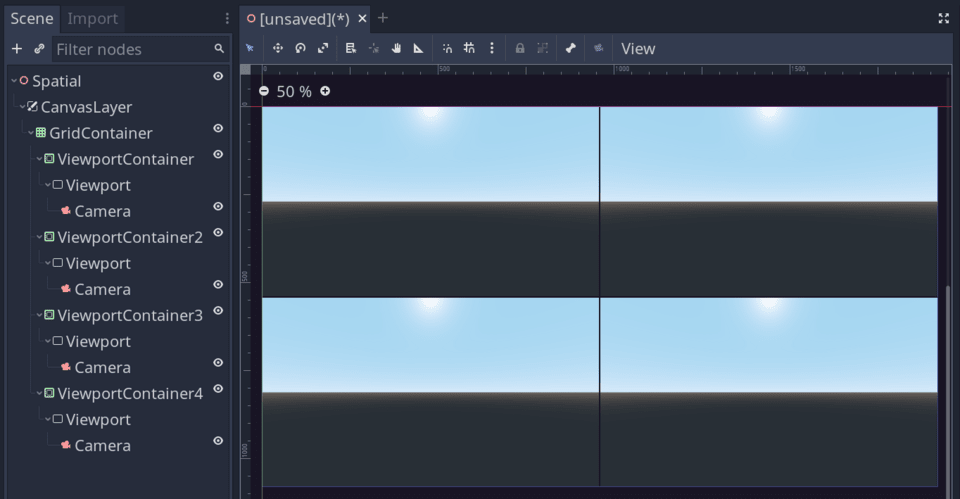

To move each player individually, you’ll need to assign them different controls. We cover the basics in our [Local multiplayer input tutorial](https://www.gdquest.com/tutorial/godot/2d/local-multiplayer-input/).

### Taking screenshots

Screenshots are a common feature for games with social or randomly-generated content.

You can capture them using a `Viewport`, by saving their rendered image data to a file.

In this demo, we use a `CanvasLayer` with a `Label` and an `AnimationPlayer` as children. We use them to fade the label after successfully saving a screenshot image.

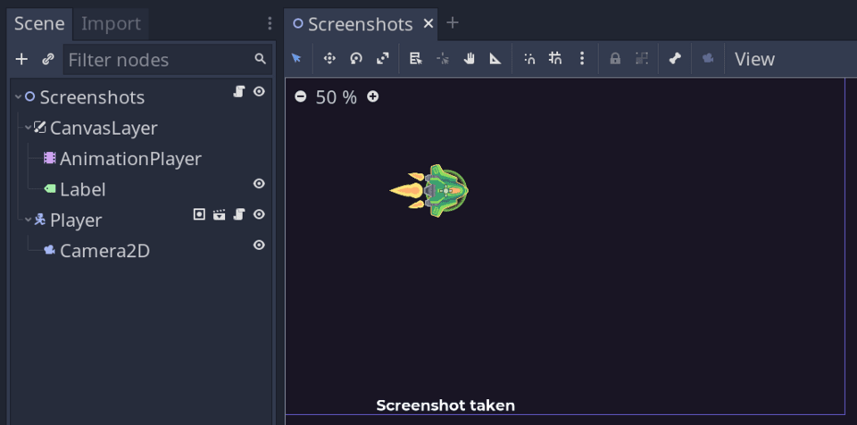

To save screenshots, we have a script that’ll access the root viewport, one created automatically by Godot at the root of our game’s scene tree.

This script generates screenshot names and gets images from the viewport.

```
# This is the template for our screenshot filenames:
#
# - %s is a placeholder to print variables as-is.
# - %02d takes a number and ensure adds leading a leading zero as necessary to
#   ensure there are always 2 digits.
#
# Example output filename: "Node_Essentials_2021-06-19_10-40-00.png"
const FILENAME_TEMPLATE := "%s_%s-%02d-%02d_%02d-%02d-%02d"

# Our Godot project's name, which we store to add in screenshot file names.
onready var game_name: String = ProjectSettings.get_setting("application/config/name")

onready var _anim_player := $CanvasLayer/AnimationPlayer
onready var _label := $CanvasLayer/Label
```

You can change your game’s name in *Project* > *Project Settings* > *Application* > *Config* > *Name*.

Now for the main event, the screenshot function. The essentials of this function are:

- Call `get_texture().get_data()` on the `Viewport` to return it as an upside-down image.
- Flip the image with `flip_y()` so it’s rightside-up.
- Call `save_png("user://filename.png")` to save it to the user folder.

Instead of saving the screenshot as `filename.png`, we can get the date and time from the `OS` to create a timestamped screenshot.

You can see some string formatting in action with the following screenshot code:

```
## Generates an image name, gets the Viewport data, and saves it as a png file in
## the user folder.
func take_screenshot() -> void:
    var date: Dictionary = OS.get_datetime()
    var image_name = (
        FILENAME_TEMPLATE % [
            game_name,
            date["year"],
            date["month"],
            date["day"],
            date["hour"],
            date["minute"],
            date["second"]
        ]
    )
    # We get the root viewport's texture data to save it as an image file. The
    # function returns the rendered pixels.
    var image: Image = get_viewport().get_texture().get_data()
    # In OpenGL images render mirrored vertically.
    #
    # Godot automatically flips images when displaying them on your screen, but
    # here, we need to do it manually.
    image.flip_y()
    # And finally, we save the screenshot to the user's directory using the
    # image's save_png() method.
    image.save_png("user://%s.png" % [image_name])
    # We display a label to notify the player we saved a screenshot.
    _label.text = "Screenshot taken: \"%s\"" % [image_name]
    _anim_player.stop(true)
    _anim_player.play("fade")
```

We use string formatting to integrate the date and time into the filename as a single string. The `% []` at the end goes through every percent sign, and replaces them with the variables in the brackets

You can learn more about Godot string formatting by reading [GDScript Format Strings on the Godot docs.](https://docs.godotengine.org/en/stable/getting_started/scripting/gdscript/gdscript_format_string.html)

Lastly, we need to bind one key to take screenshots, and another key to open the screenshot folder:

```
func _unhandled_input(event: InputEvent) -> void:
    # We set this action to F9 in our project.
    if event.is_action_pressed("take_screenshot"):
        take_screenshot()
    # And we mapped this action to F10.
    if event.is_action("open_user_directory"):
        open_user_directory()
```

Here is the function to open the directory in which we save screenshots.

```
## Opens the user:// folder. This code works on all supported platforms.
func open_user_directory() -> void:
    OS.shell_open(OS.get_user_data_dir())
```

You should now be able to take screenshots without UI in the way.

In this example, we used the `user://` directory to save screenshots. You can learn more about it [in the official manual](https://docs.godotengine.org/en/stable/tutorials/io/data_paths.html#user-path-persistent-data)

### Placing Labels in 3D

In MMOs, nametags are essential to know who you’re playing with.

[figure not shown]

You can add labels in 3D by rendering them to a texture, then displaying this texture on a `QuadMesh` in the 3D world.

To do so, you need a `Viewport`, a `Label`, and a `MeshInstance`.

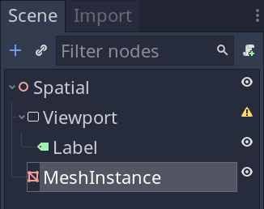

The `Viewport` renders the `Label` and we display its output via a material assigned to the `MeshInstance`’s *Mesh* via a `ViewportTexture`.

When using viewports as render targets, the scene tree order matters. The mesh’s texture has to pull from the viewport after rendering, so the mesh should be below the viewport node in the scene tree.

Then, `Viewport` nodes render images flipped vertically by default.

As a result, the `Viewport` node should have *Render Target -> V Flip* enabled, otherwise the `ViewportTexture` will appear upside-down.

You should also enable *Transparent Bg* to render the label over a transparent background.

Then, we want to assign a `QuadMesh` to the `MeshInstance`’s *Mesh* property. This is essentially a flat surface like `PlaneMesh`, although we can make it always face the camera.

#### Sizing the viewport and mesh

The viewport and mesh both have a *Size* property. To prevent the label from looking squished, they need to use the same aspect ratio.

We’re using a ratio of `3:1` by setting the viewport size to `Vector2(300, 100)` and mesh size to `Vector2(3, 1)`.

The `MeshInstance`’s *Mesh* should have a `SpatialMaterial` with the *Flags -> Transparent* and *Flags -> Unshaded* turned on to render the text without the scene’s lights affecting it.

[figure not shown]

You also want to assign a `ViewportTexture` as its *Albedo -> Texture*. Set it to target your label’s viewport and you should be able to see the text in your 3D scene.

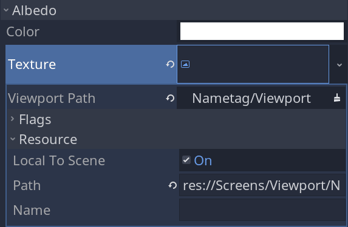

To make the text always face the camera, set the material’s *Parameters -> Billboard Mode* to *Particle Billboard*.

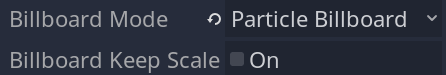

**Note:** If you get the error `Can't create a ViewportTexture on this resource because it's not set as local to scene`, check that both the `QuadMesh` resource and its `SpatialMaterial` have their *Resource -> Local To Scene* property turned on.

If you want your nametags to fade out over distance, set *Distance Fade -> Mode -> Pixel Alpha*.

You can use *Max Distance* and *Min Distance* to control the distance. Making *Max Distance* smaller than *Min Distance* will fade the nametag out as you get further away.

The nametag should be floating around in 3D space now! Objects in front of the nametag will hide it.

You can also add code to change the `Label` at runtime. For example, you can connect a `LineEdit` node’s `text_changed` signal to match the `Label`’s text:

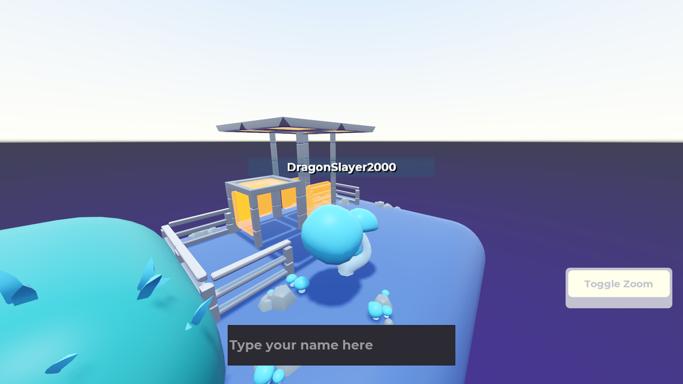

```
func _on_LineEdit_text_changed(new_text: String) -> void:
    _nametag_label.text = new_text
```

**Note:** if any viewport-related errors have come up in the console, go to the Troubleshooting section of this guide.

**Note:** You can use `Sprite3D` for nametags instead of a `MeshInstance`.

`Sprite3D` has the upside of scaling itself using *Pixel Size*. `MeshInstance` has the upside of letting you use shapes other than squares. In either case, you’ll need to use a `ViewportTexture`.

### 3D character in 2D world

Some games use 3D models over a 2D world. For example, *Oxenfree* uses painted 2D backgrounds, but displays its characters in 3D.

[figure not shown]

*Game: Oxenfree (2016)*

A `Viewport` and `Sprite` can be added to a 2D character controller. The `Viewport` should have a `Camera`, and 3D skin as children:

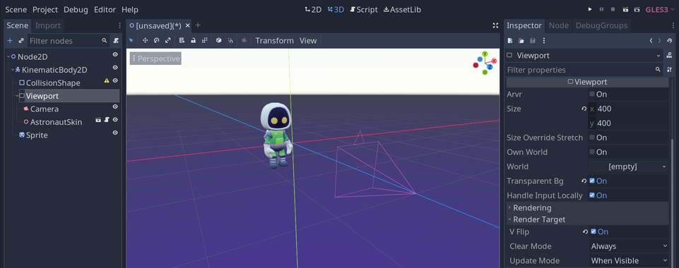

The camera points at the *AstronautSkin* node to show it on the `Viewport`. Then, the `Sprite` is given a `ViewportTexture` that points at the `Viewport`, showing the 3D scene in 2D.

Make sure the `Viewport` has *Transparent Bg* and *Render Target -> V Flip* enabled. You should be able to see your 3D scene through the `Sprite`.

[figure not shown]

If there’s any issues, check the Troubleshooting section of this guide.

Now that we can see the 3D scene in 2D, the character controller’s `CollisionShape2D` can be fit to what’s visible from the `Viewport`.

You can learn more about creating a character controller in the guide for KinematicBody2D.

### Changing graphics settings

Because `Viewport` renders the game world to the screen, it also can adjust some graphics settings. This is useful for 3D games where the user’s device will vary.

In our demo, we created a `Viewport` node in the scene to help you better understand what’s happening in Godot.

You can apply the same settings on the game’s root viewport. To get the root viewport node, call `get_viewport()` from your code.

There are four main ways a `Viewport` can adjust graphics settings:

- Size (*Resolution*)
- MSAA (*Multisample Anti*-*Aliasing*)
- FXAA (*Fast Approximate Anti*-*Aliasing*)
- Shadow atlas size

To let the user change all of these settings, we’ll add different types for the user to adjust.

`OptionButton` is useful when we want to show the user a detailed list, like screen resolutions and MSAA settings.

`HSlider` adjusts a single value, we use this to give a general “low, medium, high, max” option for shadow quality.

`CheckBox` is good for boolean settings like FXAA.

We put these `Control` nodes in `VBoxContainer` and `HBoxContainer` nodes so Godot could line them up automatically. Using containers like this is optional, and only the two `OptionButton` nodes, the `HSlider`, and the `CheckBox` are necessary:

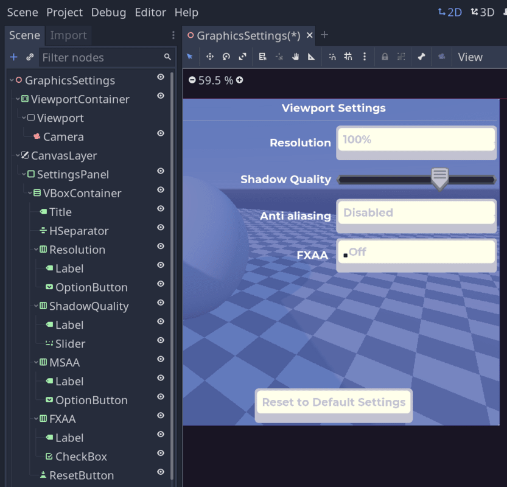

In a script on the root, we can save some setup time by connecting the `Control` nodes to functions we’ll create in the future.

```
export var target_viewport := NodePath()

onready var _viewport: Viewport = get_node(target_viewport)

onready var _resolution: OptionButton = $VBoxContainer/Resolution/OptionButton
onready var _shadow_quality: Slider = $VBoxContainer/ShadowQuality/Slider
onready var _MSAA: OptionButton = $VBoxContainer/MSAA/OptionButton
onready var _FXAA: CheckBox = $VBoxContainer/FXAA/CheckBox


func _ready():
    _populate_resolutions()

    _resolution.connect("item_selected", self, "set_resolution")
    _shadow_quality.connect("value_changed", self, "set_shadow_quality")
    _MSAA.connect("item_selected", self, "set_msaa")
    _FXAA.connect("toggled", self, "set_fxaa")
```

The `_populate_resolutions()` function needs to be made ahead of time since it’s called in `_ready()`. Keep `_populate_resolutions()` blank for now:

```
func _populate_resolutions -> void:
    pass
```

Before moving on, we need to choose which `Viewport` to adjust, and set the `target_viewport` variable in the *Inspector*. Point this to the `Viewport` node in the scene.

If you want to use the root `Viewport`, delete the `target_viewport` variable and assign `_viewport` to the root instead:

```
onready var _viewport: Viewport = get_tree().get_root()
```

The rest of the guide will go through what each property does, and how to adjust these properties with the `Control` nodes we laid out earlier.

#### Size (Resolution)

Godot does not change the user’s monitor resolution like other engines. In fullscreen, the root `Viewport` changes its size to match your game window. This is a problem in 3D, where some users with a high-resolution monitor (4k, 2k, etc.) can’t render 3D at their monitor’s native resolution.

The solution is to reduce the `Viewport`’s *stretch transform*. This is a coordinate system unique to viewports that let them reduce their rendered pixels, while keeping their size and position on-screen.

If the `Viewport` has *Size Override Stretch* enabled then the size property will instead change the stretch transform.

You can quickly change a viewport’s stretch transform through a `ViewportContainer` by:

1. Enabling *Stretch* on `ViewportContainer`.
2. Adjusting the *Size* on the `Viewport`.

Your viewport will remain in the same place on the screen, but its resolution will be different. The viewport’s stretch transform is changed, so the density of pixels over the screen changes. You can return the viewport to normal by unchecking *Stretch*.

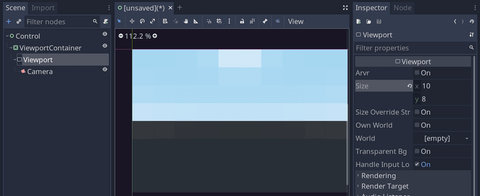

If we want the user to adjust the `Viewport` stretch transform like this, we can give users a drop-down list of common resolutions like in other game engines.

The `OptionButton` node is great at drop-down options. We can use one that we first added in the setup. First, create a list of common resolutions to support in scene’s script:

```
const SUPPORTED_RESOLUTIONS := [
    Vector2(1920, 1080),
    Vector2(1366, 768),
    Vector2(1280, 720),
    Vector2(960, 540),
]
```

Then, you can fill in the empty `_populate_resolutions()` function to pass this list of resolutions to the `OptionButton`. This will give it selectable items based on the supported resolutions list:

```
## Fills the resolution drop-down menu with supported resolutions.
func _populate_resolutions() -> void:
    for index in SUPPORTED_RESOLUTIONS.size():
        var resolution: Vector2 = SUPPORTED_RESOLUTIONS[index]
        var resolution_as_string := "{x}x{y}".format({x = resolution.x, y = resolution.y})
        _resolution.add_item(resolution_as_string, index)
```

We need one more function to read the `OptionButton`’s selected index, and to set the `Viewport`’s size as needed.

From the `_ready()` function set up earlier, this function is already connected to the `OptionButton`’s `item_selected` signal.

```
func set_resolution(index: int) -> void:
    assert(
        index < SUPPORTED_RESOLUTIONS.size(),
        "Trying to set the viewport to an unsupported resolution."
    )
    _viewport.size = SUPPORTED_RESOLUTIONS[index]
```

You should be able to modify the resolution of your game on a `Viewport` node. You can look to other parts of this guide for other graphics options.

To adjust the stretch transform of the root `Viewport`, enable `size_override_stretch` in code, and use `set_size_override()` to set its size and position:

```
onready var _root := get_tree().get_root()

func _ready() -> void:
# enable using the stretch transform to adjust resolution
    _root.set_size_override_stretch(true)
# set window size to 1920 x 1080, set the Viewport's top-left corner to window's
# top-left corner
    _root.set_size_override(true, Vector2(1920, 1080), Vector2(0,0))
# set stretch transform to 400 pixels by 400 pixels
    _root.size = Vector2(400, 400)
```

You can adjust the first `Vector2` of `set_size_override()` to change the game window size. The `_root.size` represents the stretch transform.

#### MSAA (Multisample Anti-Aliasing)

MSAA, or *Multisample Anti*-*Aliasing*, helps prevent jagged edges in games by fetching more data per pixel before drawing the screen’s contents.

The options for MSAA are 2x, 4x, 8x, and 16x. There are also equivalents of 2x and 4x intended for AndroidVR, which we will not use here.

`OptionButton` provides a dropdown list of items, and each item has an index. We can read the selected item’s index to set the viewport’s MSAA value.

```
func set_msaa(level: int) -> void:
    _viewport.msaa = level
```

If you did the setup earlier, this function will already be connected to the `OptionButton`’s `item_selected` signal.

Now that the script is setup, the `OptionButton` needs items added manually. Click on the *2D* view, then click *Items* at the top of the editor view. Add five items and give the items these names:

- Disabled
- 2x
- 4x
- 8x
- 16x

Your settings menu will now let you adjust MSAA on the `Viewport`.

#### FXAA (Fast Approximate Anti-Aliasing)

FXAA or *Fast Approximate Anti-Aliasing* is a quicker way to smooth out the edges of geometry than MSAA.

It takes the contents of the screen and blurs it. This is a cheap way to avoid sharp edges, but it can degrade visual detail.

From the earlier setup, the `CheckBox` in the `_ready()` script is already connected to the `Viewport`’s FXAA setting. `Viewport` has a function called `set_fxaa()` which is either `true` or `false`.

Look back to your `_ready()` script from setup, and notice this line that connects the pressed state of the `CheckBox` to the FXAA setting on the `Viewport`:

```
_FXAA.connect("toggled", self, "set_fxaa")
```

#### Shadow atlas size

Shadow atlas size is the amount of texture space given to the engine to render realtime shadows. The higher the atlas size, the sharper and more-accurate the shadows will be, at the cost of performance.

This guide will use an `HSlider` with four levels of shadow quality to adjust. It will adjust both the `Viewport`’s shadow atlas size, and the `ProjectSettings` for shadow filtering. Both shadow settings are adjusted to highlight what’s changeable from the user’s perspective.

Check that the `HSlider` has a *Max Value* of `3` and a *Min Value* of `0`.

Back in the main script, we need to recreate the `ProjectSettings` enumerations for shadow filtering, so we know which filtering setting we’re using.

Disabled filtering means jagged, aliased shadows. PCF5 provides smooth shadows as a tradeoff between quality and performance. PCF13 shadows are even smoother, and run slower. We’ll map these to the `HSlider`’s four settings, leaving the first setting to disable shadows entirely.

```
enum ShadowFilter { DISABLED, PCF5, PCF13 }

# Maps slider values to ShadowFilter settings
const SHADOW_SLIDER = {
    0 : ShadowFilter.DISABLED,
    1 : ShadowFilter.DISABLED,
    2 : ShadowFilter.PCF5,
    3 : ShadowFilter.PCF13
}
```

A shadow atlas size of `1` will result in very splotchy shadows, instead of setting the slider value to the atlas size, we’ll use a default size of `1024` and go from there. This script also points to the `ProjectSettings` shadow filtering path.

```
const SHADOW_FILTER_SETTING := "rendering/quality/shadows/filter_mode"
const DEFAULT_SHADOW_ATLAS_SIZE := 1024
```

Now we can create the function that will change our shadow filtering and shadow atlas size when the `HSlider` is adjusted:

```
func set_shadow_quality(value: int):
    assert(
        value < SHADOW_SLIDER.size(),
        "Trying to set shadow filtering to an unmappped value."
    )
    # enable space for the shadows, otherwise don't give them space to render
    _viewport.shadow_atlas_size = DEFAULT_SHADOW_ATLAS_SIZE if value != 0 else 0
    # The Project-wide shadow filtering is the main visual change in this slider
    ProjectSettings.set(SHADOW_FILTER_SETTING, SHADOW_SLIDER[value])
```

This script uses a ternary to check if the `HSlider` is zero. If it is, the shadow atlas size becomes zero, and shadows are disabled for the `Viewport`. Otherwise, they’re set to the default.

You can read more about the many different settings for shadows in the [Godot docs tutorial on lights and shadows.](https://docs.godotengine.org/en/stable/tutorials/3d/lights_and_shadows.html)

#### Reset to default settings

Some users can get lost in understanding what certain graphics settings do, and may accidentally enable or disable a setting that drastically changes performance or visual quality.

This step shows setting up one default, but you can always add more buttons for preset “high,” “medium,” and “low” settings.

With all of our setter functions and `Control` node connections, we can set the sliders back to their defaults. The `HSlider` and `CheckBox` nodes will automatically emit appropriate signals when their values change in code. For `OptionButton` nodes, this isn’t the case, so we need to use our setter functions to update the `Viewport` resolution and MSAA.

```
func reset_to_default_settings() -> void:
    _shadow_quality.value = ShadowFilter.PCF13
    _FXAA.pressed = false
    _resolution.select(0)
    set_resolution(0)
    _MSAA.select(0)
    set_msaa(0)
```

### Making 3D Portals

This demo is about creating dimensional doors and other teleporters, as seen in the game *Portal*. At least, this demo covers the foundations to display another part of the world.

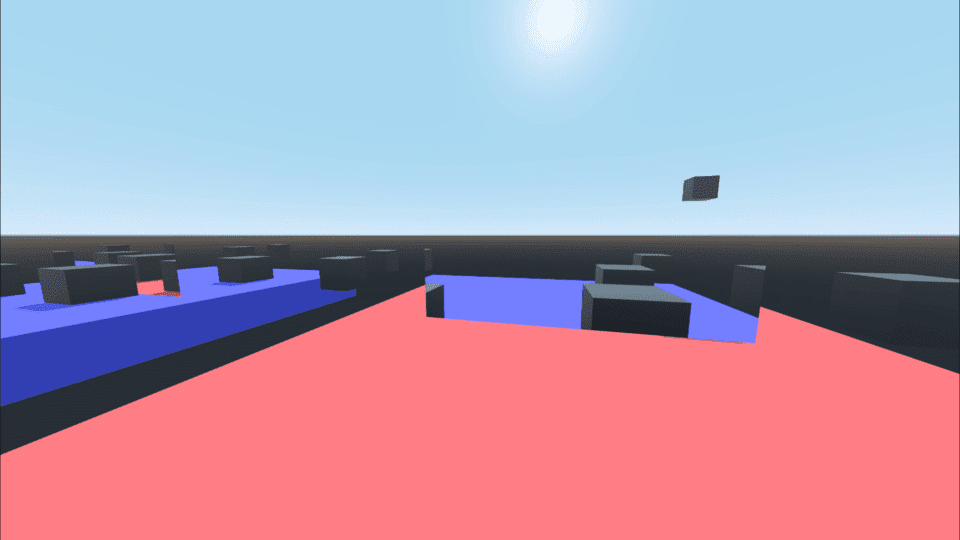

**Note:** Godot 3 lacks some features to create complete portals that would clip objects passing through them. You can learn more in this proposal: [Godot proposals: add CameraMatrix to Variant](https://github.com/godotengine/godot-proposals/issues/2713).

Portals are views into another part of your game world. The player looks at some surface, and through it, they see another part of the game world.

Also, we typically want to connect two of such portals: one displays what is on the other side, and vice versa.

To achieve that, we need to render a different area as if the player was looking into it, relative to the portals’ positions and angles.

More precisely, you need to create a camera you position relative to the target part of the world you want to display (the pink line below).

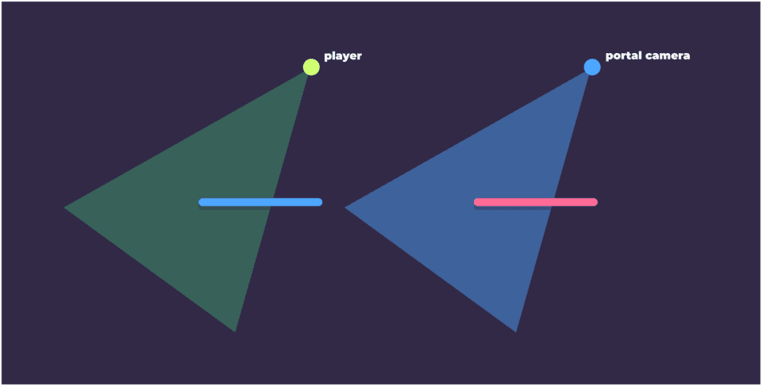

Then, you need to offset it from the target, both in terms of position and rotation: the position and rotation of the player’s camera relative to the portal they are looking at.

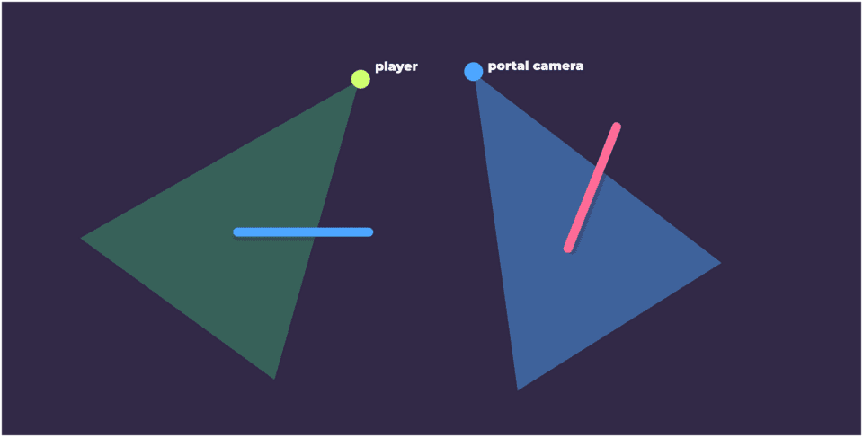

And, of course, to render that other view of the world, we need a `Viewport`.

In this demo, our portals consist of a plane, the surface on which we display the other side of the world, a `Viewport`, and a `Camera`.

[figure not shown]

In code, we want to move that camera to the target portal to render what is in that other part of the game world.

We also need to calculate the player’s transform relative to this portal. To do so, we can export some node paths and get the corresponding nodes at the start of the game.

```
extends Spatial

## This is the path to the target portal we want to connect to this one.
export var target_path := NodePath()
## And this is the path to the player's camera/
export var player_camera_path := NodePath()

var _target: Spatial
var _player_camera: Spatial

## This portal's camera, which we place at the target portal's location.
onready var _camera: Camera = $Viewport/Camera


func _ready() -> void:
    _target = get_node(target_path)
    _player_camera = get_node(player_camera_path)
```

We then place the camera at the target location.

Below, I first calculate the position offset of the player’s camera, then the rotational offset. Both are relative to the portal the player is looking at.

```
func _physics_process(_delta: float) -> void:
    # We calculate the player's offset from the portal.
    var player_offset := to_local(_player_camera.global_transform.origin)
    # Then, we place the camera at the target portal and apply the player's offset.
    _camera.transform.origin = _target.global_transform.origin + player_offset

    # For the rotation, similarly, we calculate the rotational offset between the portal and the player.
    var local_rotation := global_transform.basis.inverse() * _player_camera.global_transform.basis
    # Then, we add that rotation to the target portal's current rotation.
    _camera.global_transform.basis = _target.transform.basis * local_rotation
```

If you’re unfamiliar with 3D transforms, you can learn more down below: What the origin and basis do.

#### Displaying and cropping the viewport’s texture

With the two exported `NodePath` properties, you can set up a portal by instantiating it in the game world and assigning nodes in the *Inspector*.

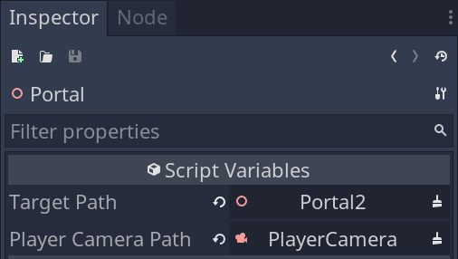

Once you create and assign the node paths for two portals, you can’t just display what the `Viewport` renders on your mesh: each portal’s `Viewport` renders the full camera’s view, but the mesh only takes a portion of the screen.

We want to map the portion of our `ViewportTexture` that corresponds to the surface of our portal in the view, which requires a shader. Luckily, in Godot, you only need a simple one.

```
shader_type spatial;
// Here, I don't want to cast shadows on the portal: I want a crisp view of the other side of the world. So I turn off any shading on this surface with the unshaded render mode.
render_mode unshaded;

// We assign a viewport texture targeting the portal viewport to this property.
uniform sampler2D portal_texture;


void fragment() {
    // Godot provides a property that directly maps the surface the mesh takes on the screen.
    // We use it to sample our texture, effectively cropping the rendered view to the portal's mesh.
    vec4 color = texture(portal_texture, SCREEN_UV);
    // And we output the pixels sampled from our portal viewport onto the screen.
    ALBEDO = color.rgb;
}
```

You want to assign that shader to a material on the portal’s surface.

You also need to ensure that every resource is local to the scene, meaning that every portal will get a unique `ViewportTexture` resource, a unique copy of the shader, and the material.

Under every resource in Godot, you can set that by expanding the folded `Resource` category.

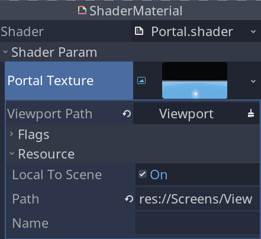

#### What the origin and basis do

While short, the code to calculate the camera’s offset can seem like magic if you’re new to working with transforms. So here are some explanations regarding a transform’s origin and basis.

Godot exposes every node’s transforms and encourages you to work with them, as this leads to code that is often efficient to write and run.

A 3D transform is mainly composed of two elements: the origin and the basis. You can think of them respectively as the node’s position and its local 3D axes.

When dealing with `global_transform`, the `origin` is the node’s position relative to the world’s origin.

If you use the `transform` property instead, you are dealing with the position relative to the parent node.

The transform’s `basis` represents the node’s local axes, giving us information about its rotation and scale. It is a set of three vectors that define the node’s transformation axes.

You can see that in the editor when you toggle the transform gizmo between the world and local modes in the toolbar.

When we multiply two basis, we apply a node’s rotation onto another. If you inverse the basis, you remove that rotation from the basis you multiplied with.

Note that the order of operations matters here: you apply the basis on the left of the multiplication sign to the one on the right.

## Your questions

### How do I move a Viewport node on-screen?

If you want to position a minimap, you’ll want to move the node holding or showing the `Viewport`’s contents.

For `Control` nodes like `TextureRect` and `ViewportContainer`, change the `rect_position` and `rect_size` properties. For a `Node2D` like a `Sprite`, change the position property.

**Note:** A `Sprite` will automatically adjust its scale to fit the `Viewport`’s size property, so `Sprite` scale should be adjusted on the `Viewport` instead to avoid resampling issues.

### How do I change the size of my Viewport?

When a `Sprite` has a `ViewportTexture`, it will automatically adjust its scale based on the `Viewport` size. Instead of changing the scale, you should change the size of the `Viewport` to avoid resampling issues.

If you want to change the resolution of a `Viewport` without changing its apparent size on-screen, the `Viewport` has to be a child of a `ViewportContainer`. When the `ViewportContainer` has stretch enabled, you can adjust the size of the `Viewport` without changing its apparent size on-screen.

Changing a `ViewportContainer`’s `rect_size` will stretch the look of the `Viewport`. You should change the margin properties of the `ViewportContainer` instead.

### How do I make my screen fit to any window size?

If you run a 2D scene with some details, and expand the window, you’ll see beyond the usual playable space. While this can be partially solved by adding a `Camera2D` node, you can also lock the root `Viewport`’s aspect ratio to prevent it from showing outside the bounds of 2D.

This is not an issue in 3D since the `Camera` node adjusts what it can render automatically based on the screen size.

You can read more about this topic with stretch mode and aspect in the [Godot docs article for Multiple Resolutions.](https://docs.godotengine.org/en/stable/tutorials/viewports/multiple_resolutions.html)

### How should I structure my scene with a Viewport?

Scene structure with a `Viewport` depends on the game. If you don’t need more than one view at a time, you don’t need a `Viewport` node. You can rely on Godot’s root viewport instead.

A `Camera2D` gives you more control over how your root viewport is panned and zoomed. You can read more about this node in the guide for Camera2D.

A `Camera` enables you to see the 3D world from the root viewport.

If you are using a secondary view, such as split screen, you can add any node as a child of the `Viewport`:

- `Control` nodes will display inside their parent `Viewport`.
- `Node2D` nodes are visible from any `Camera2D`, regardless of `Viewport`.
- `Spatial` nodes are visible from any `Camera`, regardless of `Viewport`.

### How do I hide nodes from a Viewport?

Assuming that you want a node to be visible in one `Viewport`, but hidden in another, there are two ways to control visibility: worlds and culling masks.

Viewports in 3D can adjust the `cull_mask` property of their `Camera`. This will show or hide any objects on that 3D render layer. Any visible 3D object in-game can be set to use a specific 3D render layer.

Render layers are a lot like the physics layers for collisions, except they only control visibility. You can name these 3D render layers in *Project Settings* > *Layer Names* > *3D Render*.

Worlds are more involved. Two nodes in their own worlds will have separate rendering and collision. This is one way to control what is visible and collidable between `Viewport`.

- Worlds in 3D can be set in the *Inspector*, by creating a new `World` resource, and enabling *Own World*.
- `World2D` is only editable through code, by accessing `Viewport.world2d`.

### How do I change the root viewport resolution at runtime?

In a 3D game, you generally want to let the player control the game’s resolution.

Lowering the resolution allows them to get better rendering performance.

At runtime, you can access the root viewport, which renders to the user’s display, with `get_tree().get_root()`. You can then change its `size` property to resize the viewport.

```
func _ready() -> void:
    # Set the root resolution to 960 by 540
    get_tree().get_root().size = Vector2(960, 540)
```

Note that this only affects the root viewport.

Suppose your game uses many viewports to render visual effects. In that case, you may want to iterate over them and change their resolution accordingly.

One way you could do that is with an *Autoload* (Godot’s equivalent of singletons).

You would have every `Viewport` node register itself there and let the singleton emit a signal to update their sizes.

### How do I find out when a node has gone off-screen?

You may want to disable enemy functionality until they’re shown on-screen.

You can use `VisibilityEnabler2D` and `VisibilityNotifier2D` for this. Both have different effects when they’re a child of a `Node2D`

- `VisibilityEnabler2D` freezes and pauses different parts of *Nodes* that are off-screen, without the need to use code.
- `VisibilityNotifier2D` provides helper signals like `screen_entered` and `screen_exited` for coding custom functions.

## Troubleshooting

This section covers general troubleshooting tips related to `Viewport`.

### Why doesn’t my Viewport show anything?

`Viewport` can be complex to work with, and there’s several ways they won’t display as expected. Here’s some ways to check the `Viewport`, `ViewportContainer`, and code to figure out what’s gone wrong.

All `Viewport`:

- Make sure each `Viewport` has a `Camera2D` or `Camera` as a child.
- Enable the *Current* property on the `Viewport`’s camera.
- Check that the `Viewport` size is large enough (example: x = `500` , y = `500`) to let you see some details.
- Click the hide icon, then click the show icon in the *Scene* dock to update the editor’s preview of any `ViewportTexture` resources and containers.
- Set *Clear Mode* and *Update Mode* to *Always*.

**Note:** You can return the *Update Mode* and *Clear Mode* properties to default values to help optimize the viewport.

`ViewportContainer`:

- Adjust the container’s margins in the 2D editor using the selection tool.
- Enable the container’s *Stretch* property.
- Set `stretch_shrink` to `1`.

Code:

- Review any code that calls `get_texture.get_data()` on a `Viewport`, or code that assigns images to a `Texture`.

### ViewportTexture/Viewport is throwing a lot of errors

A lot of output errors can happen when setting up a `ViewportTexture`. All nodes that can carry a `ViewportTexture` ( `Sprite`, `TextureRect`, *SpatialMaterial Albedo*, etc.) are referred to as “render targets”. Here are the most common errors:

### Viewport is upside-down

If your `Viewport` is upside-down, enable *V Flip* in the *Inspector*. This is a necessary step for `ViewportTexture` resources, screenshots, and calling `get_texture.get_data()` on a `Viewport`. You can also call `flip_y()` on the image data returned from `get_texture().get_data()`.

### ViewportTexture: Path to node is invalid

`ViewportTexture` will sometimes emit this error: `ViewportTexture: Path to node is invalid.` This error occurs when the `Viewport` is lower in the scene tree than its render target (like a `Sprite` or a `TextureRect`). In practice this doesn’t stop the `ViewportTexture` from working, but the error can be fixed by:

- Making the `Viewport` a sibling or a parent of the node with a `ViewportTexture`.
- Placing the `Viewport` node above the node that has a `ViewportTexture` ( `Sprite`, `TextureRect`, or *Mesh*).
- Reassigning the `ViewportTexture`’s `viewport_path` if you rename any node shown in the `viewport_path`.

### No collision in multiplayer

If you have two `Viewport` nodes that should collide with each other (such as in split screen multiplayer) but they don’t collide, be sure to check:

- All collision layers and masks are set appropriately (multiple players should use identical layers and masks).
- `own_world` is `false`.
- The `World` resource is empty.

If these don’t work, you can manually assign worlds in code to each `Viewport`. Use `viewport_2.world = viewport_1.world` for 3D and `viewport_2.world2d = viewport_1.world2d` for 2D.

## Pro Tips

- You can read more about how to scale the root viewport with *Project Settings* instead of code by reading the [Godot docs article for Multiple Resolutions.](https://docs.godotengine.org/en/stable/tutorials/viewports/multiple_resolutions.html)
- You can call `set_attach_to_screen_rect(rect)` on a `Viewport` to attach to the root `Viewport` directly. The `Rect2` parameter determines the position and size of the new child `Viewport`. To move this attached viewport further, call the method again with a new `Rect2`.
- You can access the root `Viewport` and make adjustments by using `get_tree().get_root()` on any `Node`.
- You can get the specific `Viewport` that a node is using by calling `get_viewport()` from a node.
- Sometimes you can get an error when calling `get_texture().get_data()` at the start of the game, or on every frame. This is because Godot’s `VisualServer` hasn’t fully loaded, and the `Viewport`’s data isn’t ready. To fix this, you can use `yield(VisualServer, "frame_post_draw")` before you call `get_data()` on a `Viewport`.

### Clickable buttons in 3D

To get clickable buttons in 3D, you can check out the [GUI in 3D demo on the Godot AssetLib](https://godotengine.org/asset-library/asset/127). This system uses 3D raycasts from the mouse position to create a fake user input that reacts in 2D.

For AR and VR developers, the above demo has been adapted in Godot. The [GUI in VR addon by aaronfranke on the Godot AssetLib](https://godotengine.org/asset-library/asset/900) has the system ported for VR controllers. You can also check out [GUI in VR demo on the Godot AssetLib](https://godotengine.org/asset-library/asset/604) to try out the system.